# Лабораторная работа №14

Партиции, файловые системы, монтирование

Тукаев Тимур

Российский университет дружбы народов, Москва, Россия

14 ноября 2025

# Цель работы

## Основная цель

Получить навыки создания разделов, файловых систем и монтирования в Linux.

# Ход выполнения работы

## Просмотр дисков

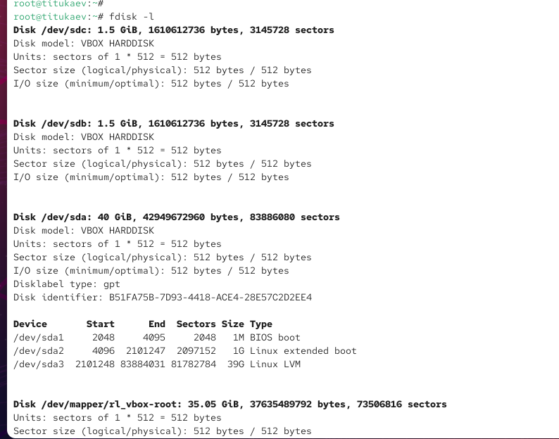

Просмотр дисков

Определены доступные устройства `/dev/sdb` и `/dev/sdc`.

## Работа с fdisk: создание MBR-разделов

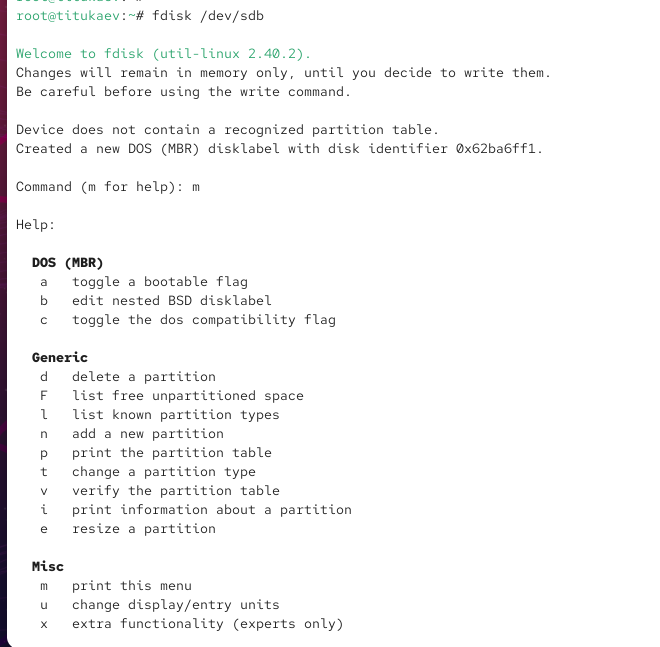

Справка fdisk

Использована утилита `fdisk` для разметки диска `/dev/sdb`.

## Создание основного раздела

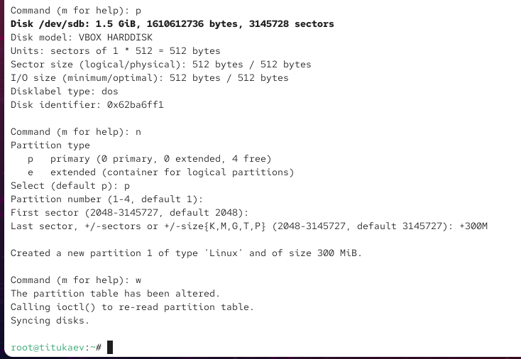

Создание основного раздела

Создан основной раздел объёмом 300 MiB.

## Проверка таблицы разделов

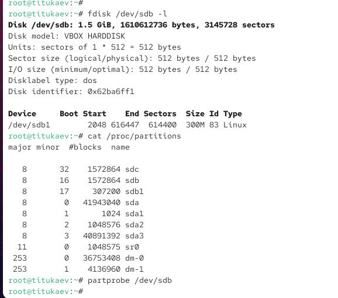

Проверка разделов

Сравнение вывода `fdisk -l` и `/proc/partitions`.

## Создание расширенного и логического разделов

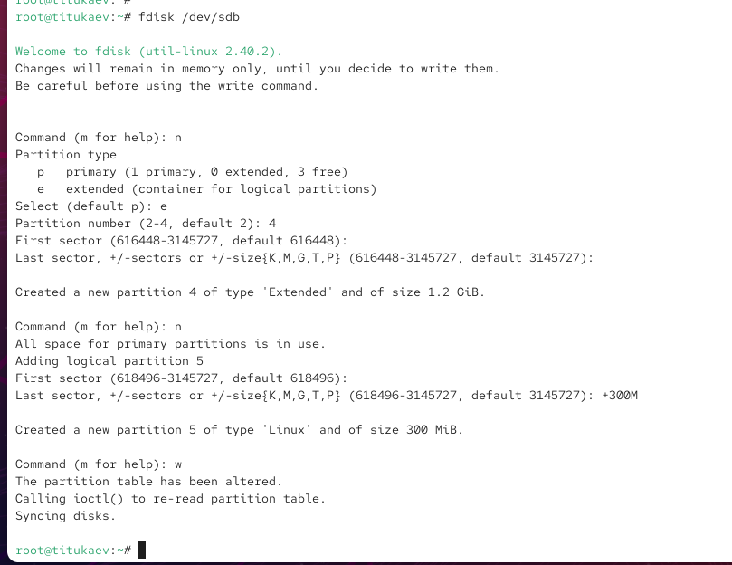

Создание расширенного и логического разделов

Созданы extended и logical-разделы.

## Проверка логических разделов

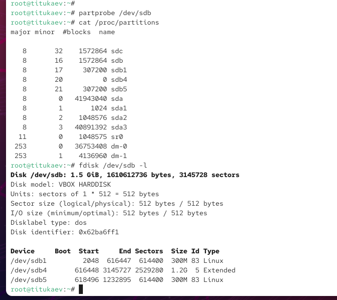

Проверка логических разделов

Разделы `/dev/sdb4` и `/dev/sdb5` отображаются корректно.

## Создание раздела подкачки

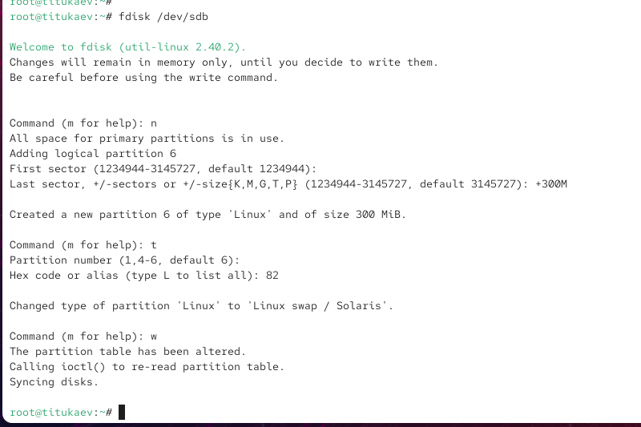

Создание swap-раздела

Создан логический раздел swap `/dev/sdb6`.

## Активация swap

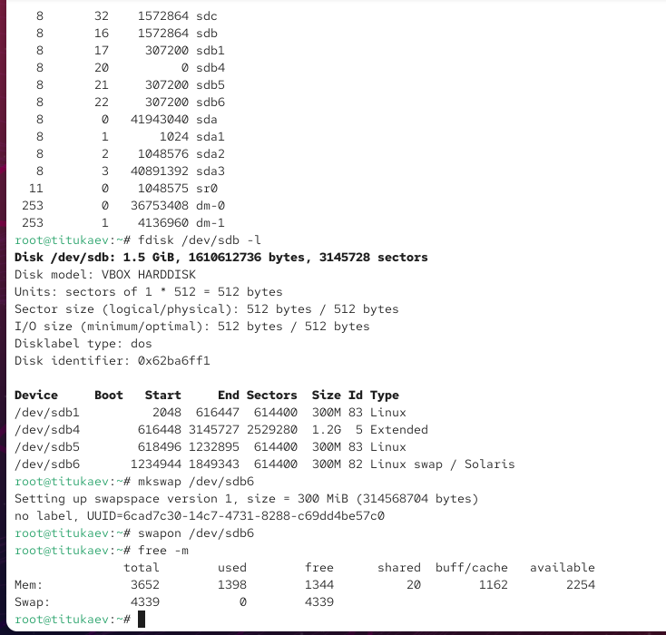

Активация swap

Выполнены `mkswap` и `swapon`.

## Работа с GPT: разметка диска

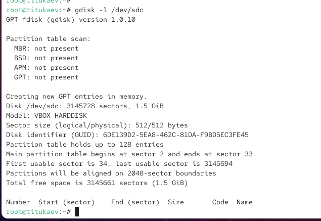

Просмотр GPT

Использована утилита `gdisk` для создания GPT-раздела.

## Создание GPT-раздела

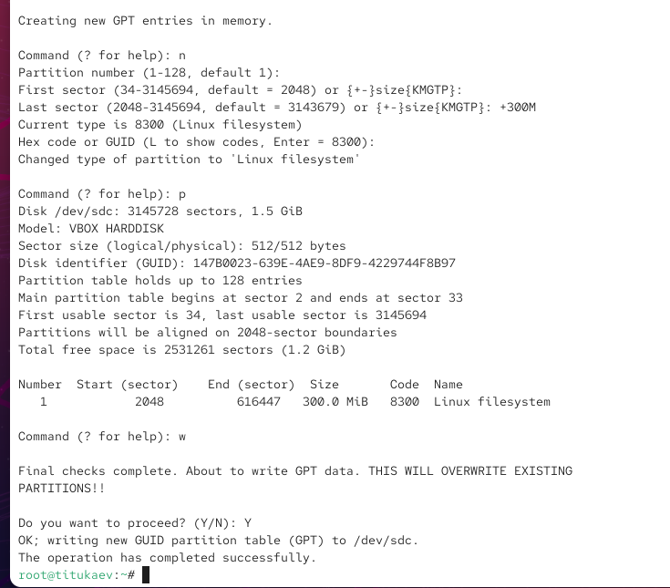

Создание GPT-раздела

Создан раздел размером 300 MiB.

## Проверка GPT

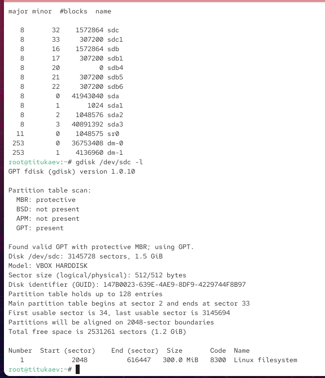

Проверка GPT-разметки

Раздел `/dev/sdc1` распознан системой.

## Форматирование XFS и EXT4

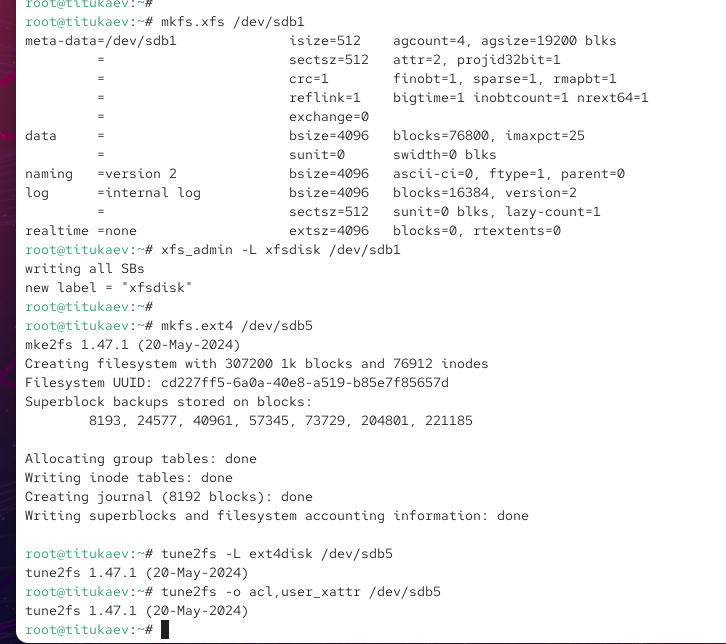

Создание XFS и EXT4

На `/dev/sdb1` создана XFS, на `/dev/sdb5` — EXT4.

## Ручное монтирование

Раздел `/dev/sdb5` смонтирован в `/mnt/tmp` и затем отмонтирован.

## UUID и настройка fstab

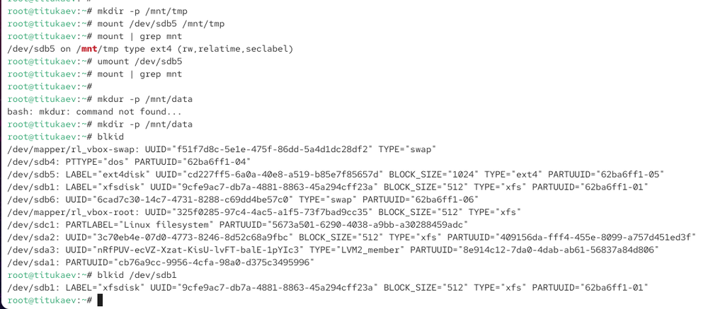

UUID устройств

Получены UUID и добавлена запись в `/etc/fstab`.

## Проверка fstab

[figure not shown]

Редактирование fstab

Автоматическое монтирование подтверждено.

## Проверка монтирования

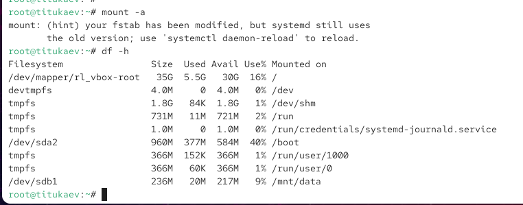

Проверка монтирования

Раздел автоматически смонтирован в `/mnt/data`.

# Самостоятельная работа

## Создание GPT-партиций

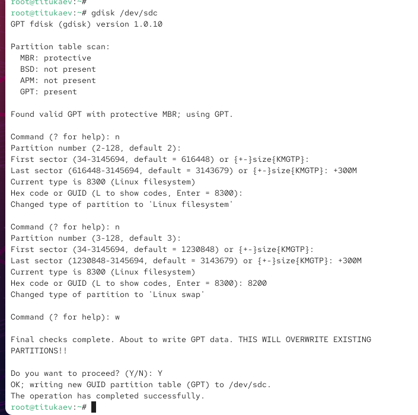

Создание GPT-разделов

## Форматирование ext4 и swap

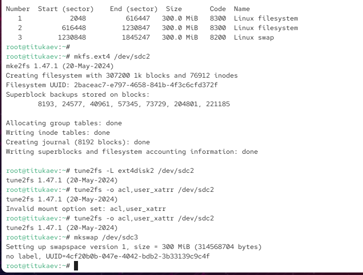

Форматирование ext4 и swap

Раздел `/dev/sdc2` — EXT4, `/dev/sdc3` — swap.

## Настройка fstab

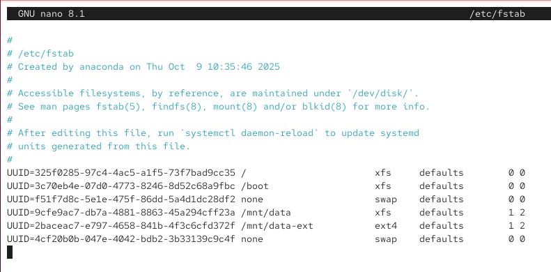

Редактирование /etc/fstab

Добавлены записи для автоматического монтирования.

## Проверка после перезагрузки

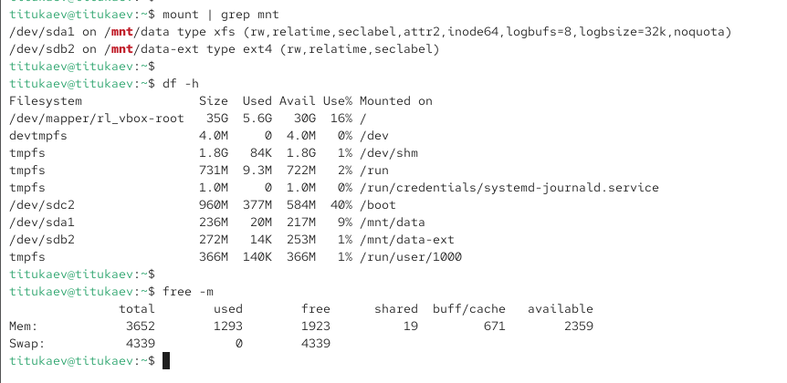

Проверка разделов

EXT4-раздел смонтирован, swap активен.

# Итоги работы

## Вывод

Были созданы MBR и GPT разделы, выполнено форматирование, настройка swap, ручное и автоматическое монтирование. Закреплены навыки работы с блочными устройствами и таблицами разделов в Linux.